# Question

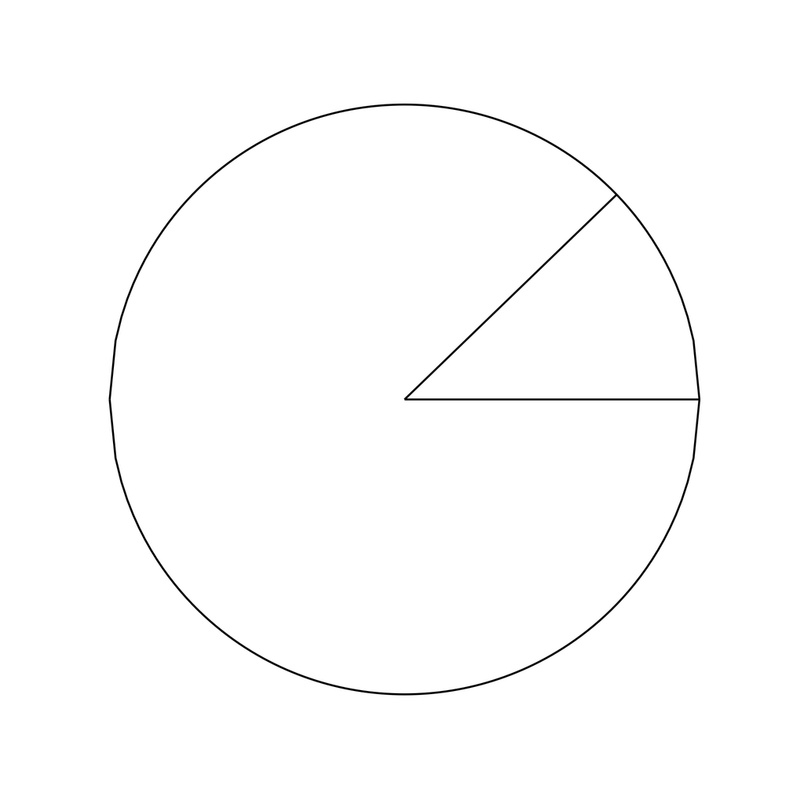

## Answerlist

- 9.37 unidades cuadradas
- 8.68 unidades cuadradas
- 0.92 unidades cuadradas
- 9.6 unidades cuadradas

# Solution

La solución se puede encontrar siguiendo estos pasos:

1. Primero, calculamos el área del sector circular:
   - Área del sector = ($\theta$/360°) × $\pi$r²
   - Área del sector = (44/360) × $\pi$ × 5² = 9.6
2. Luego, calculamos el área del triángulo formado por los radios y la cuerda:
   - Área del triángulo = (r² × sin $\theta$)/2
   - Área del triángulo = (5² × sin(44°))/2 = 8.68
3. El área del segmento circular es la diferencia entre el área del sector y el área del triángulo:
   - Área del segmento = Área del sector - Área del triángulo
   - Área del segmento = 9.6 - 8.68 = 0.92

La respuesta correcta es 0.92 unidades cuadradas.

# Meta-information

exname: Área de Segmento Circular extype: schoice exsolution: 0010 exshuffle: TRUE